# Starbucks Capstone Challenge

### Introduction

This data set contains simulated data that mimics customer behavior on the Starbucks rewards mobile app. Once every few days, Starbucks sends out an offer to users of the mobile app. An offer can be merely an advertisement for a drink or an actual offer such as a discount or BOGO (buy one get one free). Some users might not receive any offer during certain weeks.

Not all users receive the same offer, and that is the challenge to solve with this data set.

Your task is to combine transaction, demographic and offer data to determine which demographic groups respond best to which offer type. This data set is a simplified version of the real Starbucks app because the underlying simulator only has one product whereas Starbucks actually sells dozens of products.

Every offer has a validity period before the offer expires. As an example, a BOGO offer might be valid for only 5 days. You'll see in the data set that informational offers have a validity period even though these ads are merely providing information about a product; for example, if an informational offer has 7 days of validity, you can assume the customer is feeling the influence of the offer for 7 days after receiving the advertisement.

You'll be given transactional data showing user purchases made on the app including the timestamp of purchase and the amount of money spent on a purchase. This transactional data also has a record for each offer that a user receives as well as a record for when a user actually views the offer. There are also records for when a user completes an offer.

Keep in mind as well that someone using the app might make a purchase through the app without having received an offer or seen an offer.

### Example

To give an example, a user could receive a discount offer buy 10 dollars get 2 off on Monday. The offer is valid for 10 days from receipt. If the customer accumulates at least 10 dollars in purchases during the validity period, the customer completes the offer.

However, there are a few things to watch out for in this data set. Customers do not opt into the offers that they receive; in other words, a user can receive an offer, never actually view the offer, and still complete the offer. For example, a user might receive the "buy 10 dollars get 2 dollars off offer", but the user never opens the offer during the 10 day validity period. The customer spends 15 dollars during those ten days. There will be an offer completion record in the data set; however, the customer was not influenced by the offer because the customer never viewed the offer.

### Cleaning

This makes data cleaning especially important and tricky.

You'll also want to take into account that some demographic groups will make purchases even if they don't receive an offer. From a business perspective, if a customer is going to make a 10 dollar purchase without an offer anyway, you wouldn't want to send a buy 10 dollars get 2 dollars off offer. You'll want to try to assess what a certain demographic group will buy when not receiving any offers.

### Final Advice

Because this is a capstone project, you are free to analyze the data any way you see fit. For example, you could build a machine learning model that predicts how much someone will spend based on demographics and offer type. Or you could build a model that predicts whether or not someone will respond to an offer. Or, you don't need to build a machine learning model at all. You could develop a set of heuristics that determine what offer you should send to each customer (i.e., 75 percent of women customers who were 35 years old responded to offer A vs 40 percent from the same demographic to offer B, so send offer A).

# Data Sets

The data is contained in three files:

- portfolio.json - containing offer ids and meta data about each offer (duration, type, etc.)
- profile.json - demographic data for each customer
- transcript.json - records for transactions, offers received, offers viewed, and offers completed

Here is the schema and explanation of each variable in the files:

**portfolio.json**

- id (string) - offer id
- offer_type (string) - type of offer ie BOGO, discount, informational
- difficulty (int) - minimum required spend to complete an offer
- reward (int) - reward given for completing an offer
- duration (int) - time for offer to be open, in days
- channels (list of strings)

**profile.json**

- age (int) - age of the customer
- became_member_on (int) - date when customer created an app account
- gender (str) - gender of the customer (note some entries contain 'O' for other rather than M or F)
- id (str) - customer id
- income (float) - customer's income

**transcript.json**

- event (str) - record description (ie transaction, offer received, offer viewed, etc.)
- person (str) - customer id
- time (int) - time in hours since start of test. The data begins at time t=0
- value - (dict of strings) - either an offer id or transaction amount depending on the record

**Note:** If you are using the workspace, you will need to go to the terminal and run the command `conda update pandas` before reading in the files. This is because the version of pandas in the workspace cannot read in the transcript.json file correctly, but the newest version of pandas can. You can access the termnal from the orange icon in the top left of this notebook.

You can see how to access the terminal and how the install works using the two images below. First you need to access the terminal:

[figure not shown]

Then you will want to run the above command:

[figure not shown]

Finally, when you enter back into the notebook (use the jupyter icon again), you should be able to run the below cell without any errors.

### 1. Understanding Data

#### 1.1 import required libraries

```python
import pandas as pd
import numpy as np
import math
import json
import seaborn as sns
import matplotlib.pyplot as plt
from matplotlib.pyplot import show

% matplotlib inline


import progressbar
from datetime import datetime

import warnings
warnings.filterwarnings('ignore')
```

#### 1.2 Gathering Data

```python
# read in the json files
def load_data():
    portfolio = pd.read_json('data/portfolio.json', orient='records', lines=True)
    profile = pd.read_json('data/profile.json', orient='records', lines=True)
    transcript = pd.read_json('data/transcript.json', orient='records', lines=True)

    return portfolio, profile, transcript
portfolio, profile, transcript = load_data()
```

#### 1.3 Access Data

#### 1.3.1 portfolio data set

```python
portfolio.info()
```

```
<class 'pandas.core.frame.DataFrame'>
Int64Index: 10 entries, 0 to 9
Data columns (total 6 columns):
channels      10 non-null object
difficulty    10 non-null int64
duration      10 non-null int64
id            10 non-null object
offer_type    10 non-null object
reward        10 non-null int64
dtypes: int64(3), object(3)
memory usage: 560.0+ bytes
```

```python
portfolio
```

|  | channels | difficulty | duration | id | offer_type | reward |
| --- | --- | --- | --- | --- | --- | --- |
| 0 | [email, mobile, social] | 10 | 7 | ae264e3637204a6fb9bb56bc8210ddfd | bogo | 10 |
| 1 | [web, email, mobile, social] | 10 | 5 | 4d5c57ea9a6940dd891ad53e9dbe8da0 | bogo | 10 |
| 2 | [web, email, mobile] | 0 | 4 | 3f207df678b143eea3cee63160fa8bed | informational | 0 |
| 3 | [web, email, mobile] | 5 | 7 | 9b98b8c7a33c4b65b9aebfe6a799e6d9 | bogo | 5 |
| 4 | [web, email] | 20 | 10 | 0b1e1539f2cc45b7b9fa7c272da2e1d7 | discount | 5 |
| 5 | [web, email, mobile, social] | 7 | 7 | 2298d6c36e964ae4a3e7e9706d1fb8c2 | discount | 3 |
| 6 | [web, email, mobile, social] | 10 | 10 | fafdcd668e3743c1bb461111dcafc2a4 | discount | 2 |
| 7 | [email, mobile, social] | 0 | 3 | 5a8bc65990b245e5a138643cd4eb9837 | informational | 0 |
| 8 | [web, email, mobile, social] | 5 | 5 | f19421c1d4aa40978ebb69ca19b0e20d | bogo | 5 |
| 9 | [web, email, mobile] | 10 | 7 | 2906b810c7d4411798c6938adc9daaa5 | discount | 2 |

#### 1.3.2 profile data set

```python
profile.info()
```

```
<class 'pandas.core.frame.DataFrame'>
Int64Index: 17000 entries, 0 to 16999
Data columns (total 5 columns):
age                 17000 non-null int64
became_member_on    17000 non-null int64
gender              14825 non-null object
id                  17000 non-null object
income              14825 non-null float64
dtypes: float64(1), int64(2), object(2)
memory usage: 796.9+ KB
```

```python
profile.head()
```

|  | age | became_member_on | gender | id | income |
| --- | --- | --- | --- | --- | --- |
| 0 | 118 | 20170212 | None | 68be06ca386d4c31939f3a4f0e3dd783 | NaN |
| 1 | 55 | 20170715 | F | 0610b486422d4921ae7d2bf64640c50b | 112000.0 |
| 2 | 118 | 20180712 | None | 38fe809add3b4fcf9315a9694bb96ff5 | NaN |
| 3 | 75 | 20170509 | F | 78afa995795e4d85b5d9ceeca43f5fef | 100000.0 |
| 4 | 118 | 20170804 | None | a03223e636434f42ac4c3df47e8bac43 | NaN |

```python
# missings values count
profile.isnull().sum()
```

```
age                    0
became_member_on       0
gender              2175
id                     0
income              2175
dtype: int64
```

```python
min_age = profile.age.min()
max_age = profile.age.max()
median_age = profile.age.median()
mean_age = profile.age.mean()

# min, max, meadian, mean for income
min_income = profile.income.min()
max_income = profile.income.max()
median_income = profile.income.median()
mean_income = profile.income.mean()

# skewness along the index axis
skew = profile[['age', 'income']].skew(axis = 0, skipna = True)

# find the kurtosis over the index axis
kurtosis = profile[['age', 'income']].kurt(axis = 0, skipna = True)


descriptive_stats_dict = {'age': {'Min': min_age, 'Max': max_age,
                                  'Mean': mean_age, 'Meadian': median_age,
                                  'Skew': skew[0], 'Kurtosis': kurtosis[0]
                                  },
                          'income': {'Min': min_income, 'Max': max_income,
                                     'Mean': mean_income, 'Meadian': median_income,
                                     'Skew': skew[1], 'Kurtosis': kurtosis[1]
                                     }
                          }

descriptive_stats = pd.DataFrame.from_dict(descriptive_stats_dict, orient='index')
descriptive_stats
```

|  | Min | Max | Mean | Meadian | Skew | Kurtosis |
| --- | --- | --- | --- | --- | --- | --- |
| age | 18.0 | 118.0 | 62.531412 | 58.0 | 0.761858 | -0.004986 |
| income | 30000.0 | 120000.0 | 65404.991568 | 64000.0 | 0.402005 | -0.558372 |

**Note:**

- gender and income in profile data set have 2175 missing values.
- became_member_on should be in date format. But it seems not useful, leave as it is.
- Minimum age: 18, Maximum age: 118, Age median: 58.0, Age mean: 63.0
- Minimum income: 30000, Maximum income: 120000, income median: 64000, income mean: 65405
- skewedness for age: 0.76 and for income: 0.40. Both are close to zero. Hence, looks fine.
- Kurtosis for age: -0.004 and for income: -0.558. Both are close to zero. Hence, looks fine.

#### 1.3.3 transcript data set

```python
transcript.head()
```

|  | event | person | time | value |
| --- | --- | --- | --- | --- |
| 0 | offer received | 78afa995795e4d85b5d9ceeca43f5fef | 0 | {'offer id': '9b98b8c7a33c4b65b9aebfe6a799e6d9'} |
| 1 | offer received | a03223e636434f42ac4c3df47e8bac43 | 0 | {'offer id': '0b1e1539f2cc45b7b9fa7c272da2e1d7'} |
| 2 | offer received | e2127556f4f64592b11af22de27a7932 | 0 | {'offer id': '2906b810c7d4411798c6938adc9daaa5'} |
| 3 | offer received | 8ec6ce2a7e7949b1bf142def7d0e0586 | 0 | {'offer id': 'fafdcd668e3743c1bb461111dcafc2a4'} |
| 4 | offer received | 68617ca6246f4fbc85e91a2a49552598 | 0 | {'offer id': '4d5c57ea9a6940dd891ad53e9dbe8da0'} |

```python
# unique events in transcript
transcript.event.unique().tolist()
```

```
['offer received', 'offer viewed', 'transaction', 'offer completed']
```

```python
# show top 5 rows for event "offer received"
transcript[transcript.event == 'offer received'].head()
```

|  | event | person | time | value |
| --- | --- | --- | --- | --- |
| 0 | offer received | 78afa995795e4d85b5d9ceeca43f5fef | 0 | {'offer id': '9b98b8c7a33c4b65b9aebfe6a799e6d9'} |
| 1 | offer received | a03223e636434f42ac4c3df47e8bac43 | 0 | {'offer id': '0b1e1539f2cc45b7b9fa7c272da2e1d7'} |
| 2 | offer received | e2127556f4f64592b11af22de27a7932 | 0 | {'offer id': '2906b810c7d4411798c6938adc9daaa5'} |
| 3 | offer received | 8ec6ce2a7e7949b1bf142def7d0e0586 | 0 | {'offer id': 'fafdcd668e3743c1bb461111dcafc2a4'} |
| 4 | offer received | 68617ca6246f4fbc85e91a2a49552598 | 0 | {'offer id': '4d5c57ea9a6940dd891ad53e9dbe8da0'} |

```python
# show top 5 rows for event "offer viewed"
transcript[transcript.event == 'offer viewed'].head()
```

|  | event | person | time | value |
| --- | --- | --- | --- | --- |
| 12650 | offer viewed | 389bc3fa690240e798340f5a15918d5c | 0 | {'offer id': 'f19421c1d4aa40978ebb69ca19b0e20d'} |
| 12651 | offer viewed | d1ede868e29245ea91818a903fec04c6 | 0 | {'offer id': '5a8bc65990b245e5a138643cd4eb9837'} |
| 12652 | offer viewed | 102e9454054946fda62242d2e176fdce | 0 | {'offer id': '4d5c57ea9a6940dd891ad53e9dbe8da0'} |
| 12653 | offer viewed | 02c083884c7d45b39cc68e1314fec56c | 0 | {'offer id': 'ae264e3637204a6fb9bb56bc8210ddfd'} |
| 12655 | offer viewed | be8a5d1981a2458d90b255ddc7e0d174 | 0 | {'offer id': '5a8bc65990b245e5a138643cd4eb9837'} |

```python
# show top 5 rows for event "offer completed"
pd.set_option('display.max_colwidth', -1)
transcript[transcript.event == 'offer completed'].head()
```

|  | event | person | time | value |
| --- | --- | --- | --- | --- |
| 12658 | offer completed | 9fa9ae8f57894cc9a3b8a9bbe0fc1b2f | 0 | {'offer_id': '2906b810c7d4411798c6938adc9daaa5', 'reward': 2} |
| 12672 | offer completed | fe97aa22dd3e48c8b143116a8403dd52 | 0 | {'offer_id': 'fafdcd668e3743c1bb461111dcafc2a4', 'reward': 2} |
| 12679 | offer completed | 629fc02d56414d91bca360decdfa9288 | 0 | {'offer_id': '9b98b8c7a33c4b65b9aebfe6a799e6d9', 'reward': 5} |
| 12692 | offer completed | 676506bad68e4161b9bbaffeb039626b | 0 | {'offer_id': 'ae264e3637204a6fb9bb56bc8210ddfd', 'reward': 10} |
| 12697 | offer completed | 8f7dd3b2afe14c078eb4f6e6fe4ba97d | 0 | {'offer_id': '4d5c57ea9a6940dd891ad53e9dbe8da0', 'reward': 10} |

```python
# show top 5 rows for event "transaction"
transcript[transcript.event == 'transaction'].head()
```

|  | event | person | time | value |
| --- | --- | --- | --- | --- |
| 12654 | transaction | 02c083884c7d45b39cc68e1314fec56c | 0 | {'amount': 0.8300000000000001} |
| 12657 | transaction | 9fa9ae8f57894cc9a3b8a9bbe0fc1b2f | 0 | {'amount': 34.56} |
| 12659 | transaction | 54890f68699049c2a04d415abc25e717 | 0 | {'amount': 13.23} |
| 12670 | transaction | b2f1cd155b864803ad8334cdf13c4bd2 | 0 | {'amount': 19.51} |
| 12671 | transaction | fe97aa22dd3e48c8b143116a8403dd52 | 0 | {'amount': 18.97} |

```python
transcript.info()
```

```
<class 'pandas.core.frame.DataFrame'>
Int64Index: 306534 entries, 0 to 306533
Data columns (total 4 columns):
event     306534 non-null object
person    306534 non-null object
time      306534 non-null int64
value     306534 non-null object
dtypes: int64(1), object(3)
memory usage: 11.7+ MB
```

**Note:**

- "value" column in transcript data set is not clean.
- Extract "offerid" from "value" for events "offer recieved", "offer viewed" and "offer completed" convert into string type. "reward" seems not much useful, so leaving it.
- Extract "amount" from "value" column for event "transaction".

### 2. Data Cleansing

2.1 **profile:**

- gender and income in set have missing values. Find the reason and fix it.

2.2 **transcript**

- Extract "offerid" from "value" for events "offer recieved", "offer viewed" and "offer completed" convert into string type. "reward" seems not much useful, so leaving it.
- Extract "amount" from "value" column for event "transaction".

#### 2.1 profile

- gender and income in set have missing values. Find the reason and fix it.

```
array([[<matplotlib.axes._subplots.AxesSubplot object at 0x7f3070a3b518>,
      dtype=object)
```

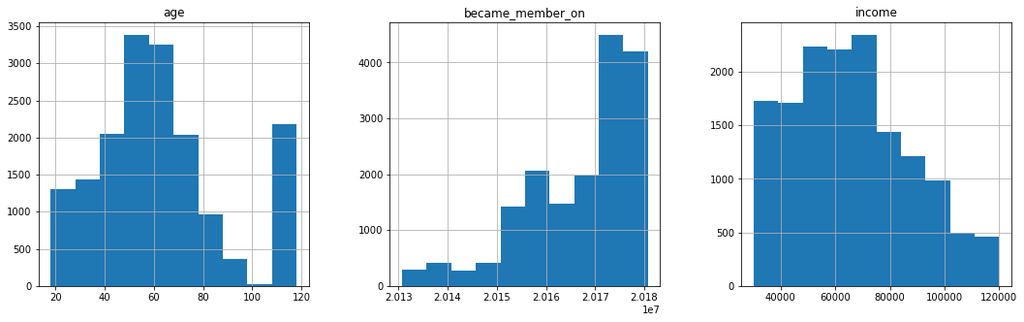

```python
# check for outliers
profile.hist( figsize=(18,5), layout=(1,3))
```

- outliers in age

```python
# check if there is any relationship between age and the missing value of gender and income
profile[profile.isnull().T.any()]['age'].unique().tolist()
```

```
[118]
```

```python
# check if for age = 118 all the value for gender and income are missing
profile[profile['age'] == 118].groupby('age').count()
```

| age | became_member_on | gender | id | income |
| --- | --- | --- | --- | --- |
| 118 | 2175 | 0 | 2175 | 0 |

**Note:** All the profiles having age = 118 does not have values for gender and income. Drop these profiles from our analysis.

```python
# drop profiles having age = 118
profile = profile[profile['age'] != 118].reset_index(drop=True)
```

```python
# check if any missing value is remaining
assert(profile.isnull().sum().sum() == 0)
```

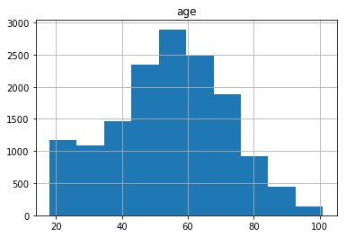

```python
# check if any outliers still exists
hist = profile.hist(column='age')
```

- All outliers have been remove.

```python
profile['gender'].unique()
```

```
array(['F', 'M', 'O'], dtype=object)
```

#### 2.2 **transcript**

- Extract "offerid" from "value" for events "offer recieved", "offer viewed" and "offer completed" convert into string type. "reward" seems not much useful, so leaving it.
- Extract "amount" from "value" column for event "transaction".

```python
# divide transcript into 1) "offer_received_viewed", 2) "offer_completed" and  3) "offer_in_transaction" data sets.
offer_received_and_viewed = transcript[transcript.event.isin(['offer received', 'offer viewed'])]
offer_completed = transcript[transcript.event == 'offer completed']
offer_in_transaction = transcript[transcript.event == 'transaction']
```

```python
# Extract "offerid" from "value" for events "offer recieved", "offer viewed" and "offer completed"
# convert into string type.
offer_received_and_viewed.loc[:, 'offer_id'] = offer_received_and_viewed.loc[:, 'value'].apply(lambda x: x['offer id'])
offer_completed.loc[:, 'offer_id'] = offer_completed.loc[:, 'value'].apply(lambda x: x['offer_id'])

# the value (amount) for these data set will be zero as there is no amount provided for these events.
offer_received_and_viewed['value'] = 0
offer_completed['value'] = 0

# extract value (amount) for in transaction
offer_in_transaction.loc[:, 'value'] = offer_in_transaction.loc[:, 'value'].apply(lambda x: x['amount']).astype('int64')
```

```python
# combine all the above three data sets
transcript = pd.concat([offer_received_and_viewed, offer_completed, offer_in_transaction])
transcript.sort_index(inplace=True)
```

```python
transcript.head()
```

|  | event | offer_id | person | time | value |
| --- | --- | --- | --- | --- | --- |
| 0 | offer received | 9b98b8c7a33c4b65b9aebfe6a799e6d9 | 78afa995795e4d85b5d9ceeca43f5fef | 0 | 0 |
| 1 | offer received | 0b1e1539f2cc45b7b9fa7c272da2e1d7 | a03223e636434f42ac4c3df47e8bac43 | 0 | 0 |
| 2 | offer received | 2906b810c7d4411798c6938adc9daaa5 | e2127556f4f64592b11af22de27a7932 | 0 | 0 |
| 3 | offer received | fafdcd668e3743c1bb461111dcafc2a4 | 8ec6ce2a7e7949b1bf142def7d0e0586 | 0 | 0 |
| 4 | offer received | 4d5c57ea9a6940dd891ad53e9dbe8da0 | 68617ca6246f4fbc85e91a2a49552598 | 0 | 0 |

#### 2.3 putting all data cleansing steps together

```python
def clean_data( profile, transcript):

    # remove outliers and missing values
    profile = profile[profile['age'] != 118].reset_index(drop=True)

    # divide transcript into 1) "offer_received_viewed", 2) "offer_completed" and  3) "offer_in_transaction" data sets.
    offer_received_and_viewed = transcript[transcript.event.isin(['offer received', 'offer viewed'])]
    offer_completed = transcript[transcript.event == 'offer completed']
    offer_in_transaction = transcript[transcript.event == 'transaction']

    # Extract "offerid" from "value" for events "offer recieved", "offer viewed" and "offer completed"
    # convert into string type.
    offer_received_and_viewed.loc[:, 'offer_id'] = offer_received_and_viewed.loc[:,
                                                                                 'value'].apply(lambda x: x['offer id'])
    offer_completed.loc[:, 'offer_id'] = offer_completed.loc[:, 'value'].apply(lambda x: x['offer_id'])

    # the value (amount) for these data set will be zero as there is no amount provided for these events.
    offer_received_and_viewed['value'] = 0
    offer_completed['value'] = 0

    # extract value (amount) for in transaction
    offer_in_transaction.loc[:, 'value'] = offer_in_transaction.loc[:, 'value'].apply(lambda x:
                                                                                      x['amount']).astype('int64')


    # combine all the above three data sets
    transcript = pd.concat([offer_received_and_viewed, offer_completed, offer_in_transaction])
    transcript.sort_index(inplace=True)


    return profile, transcript

portfolio, profile, transcript = load_data()
profile, transcript = clean_data( profile, transcript)
```

```python
profile.head()
```

|  | age | became_member_on | gender | id | income |
| --- | --- | --- | --- | --- | --- |
| 0 | 55 | 20170715 | F | 0610b486422d4921ae7d2bf64640c50b | 112000.0 |
| 1 | 75 | 20170509 | F | 78afa995795e4d85b5d9ceeca43f5fef | 100000.0 |
| 2 | 68 | 20180426 | M | e2127556f4f64592b11af22de27a7932 | 70000.0 |
| 3 | 65 | 20180209 | M | 389bc3fa690240e798340f5a15918d5c | 53000.0 |
| 4 | 58 | 20171111 | M | 2eeac8d8feae4a8cad5a6af0499a211d | 51000.0 |

```python
transcript.head()
```

|  | event | offer_id | person | time | value |
| --- | --- | --- | --- | --- | --- |
| 0 | offer received | 9b98b8c7a33c4b65b9aebfe6a799e6d9 | 78afa995795e4d85b5d9ceeca43f5fef | 0 | 0 |
| 1 | offer received | 0b1e1539f2cc45b7b9fa7c272da2e1d7 | a03223e636434f42ac4c3df47e8bac43 | 0 | 0 |
| 2 | offer received | 2906b810c7d4411798c6938adc9daaa5 | e2127556f4f64592b11af22de27a7932 | 0 | 0 |
| 3 | offer received | fafdcd668e3743c1bb461111dcafc2a4 | 8ec6ce2a7e7949b1bf142def7d0e0586 | 0 | 0 |
| 4 | offer received | 4d5c57ea9a6940dd891ad53e9dbe8da0 | 68617ca6246f4fbc85e91a2a49552598 | 0 | 0 |

```python
portfolio
```

|  | channels | difficulty | duration | id | offer_type | reward |
| --- | --- | --- | --- | --- | --- | --- |
| 0 | [email, mobile, social] | 10 | 7 | ae264e3637204a6fb9bb56bc8210ddfd | bogo | 10 |
| 1 | [web, email, mobile, social] | 10 | 5 | 4d5c57ea9a6940dd891ad53e9dbe8da0 | bogo | 10 |
| 2 | [web, email, mobile] | 0 | 4 | 3f207df678b143eea3cee63160fa8bed | informational | 0 |
| 3 | [web, email, mobile] | 5 | 7 | 9b98b8c7a33c4b65b9aebfe6a799e6d9 | bogo | 5 |
| 4 | [web, email] | 20 | 10 | 0b1e1539f2cc45b7b9fa7c272da2e1d7 | discount | 5 |
| 5 | [web, email, mobile, social] | 7 | 7 | 2298d6c36e964ae4a3e7e9706d1fb8c2 | discount | 3 |
| 6 | [web, email, mobile, social] | 10 | 10 | fafdcd668e3743c1bb461111dcafc2a4 | discount | 2 |
| 7 | [email, mobile, social] | 0 | 3 | 5a8bc65990b245e5a138643cd4eb9837 | informational | 0 |
| 8 | [web, email, mobile, social] | 5 | 5 | f19421c1d4aa40978ebb69ca19b0e20d | bogo | 5 |
| 9 | [web, email, mobile] | 10 | 7 | 2906b810c7d4411798c6938adc9daaa5 | discount | 2 |

### 3. Create user-item matrix

- 3.1. Create user-item matrix from transcript data set
- 3.1.1 Get unique customer_id's from transcript data set and customer profile details from profile dataset.

  ```
     customer_details = transcript.person + profile["age", "gender", "income"]
  ```

- 3.1.2 Create user-item matrix (customer-offer matrix) all offers (seperate column for each offer) marked as zero.

  ```
     customer_data = customer_details + ["offer_0", "offer_1", "offer_2", ..., "offer_9"]
     offer_0: represents the offer at 0 index in portfolio data set
     offer_1: represents the offer at 1 index in portfolio data set
  ```

- 3.2. Fill user-item matrix:
  - 3.2.1 Find influenced customers: customers who have recieved, viewed and completed at least on offer.
  - 3.2.2 Get transcripts for influenced customers by customer_id.
  - 3.2.3 For each influenced customer fill the user-item matrix by making an offer as 1 if influenced customer has already recieved that offer.
- 3.3. Save the user-item matrix into csv.

#### 3.1. Create user-item matrix from transcript data set

- 3.1.1 Get unique customer_id's from transcript data set and customer profile details from profile dataset.

  customer_data = transcript.person + profile["age", "gender", "income"]
- 3.1.2 Create user-item matrix (customer-offer matrix) all offers (seperate column for each offer) marked as zero.

  customer_data = customer_data + ["offer_0", "offer_1", "offer_2", ..., "offer_9"] offer_0: represents the offer at 0 index in portfolio data set offer_1: represents the offer at 1 index in portfolio data set

```python
# create user-item matrix from profile
def create_customer_matrix(df1=transcript, df2=profile, df3=portfolio):
    '''return all the transcripts for a customer
    INPUT:
        df1: transcripts data set
        df2: profile data set
        df3: portfolio data set

    OUTPUT:
        customer_data: user-item matrix having customer details in rows and offers in columns
    '''
    # get list of person id's from transcript and create customer_id column in customer_data data set
    customer_data = pd.DataFrame(df1.person.unique().tolist(), columns=['customer_id'])

    # add customer information to customer_data using profile data set
    customer_data = pd.merge(customer_data, df2, how='left', left_on='customer_id',
                             right_on='id', left_index=False, sort=True, copy=True)

    customer_data = df2[['id', 'age', 'gender', 'income']]
    customer_data.rename(columns={'id':'customer_id'}, inplace=True)



    # create columns for all the offers
    for offer in df3.index:
        customer_data['offer_'+ str(offer)] = 0


    return customer_data

customer_data = create_customer_matrix()
customer_data.head()
```

[output not shown]

#### 3.2. Fill user-item matrix:

```
* 3.2.1 Find influenced customers: customers who have recieved, viewed and completed at least on offer.
* 3.2.2 Get transcripts for influenced customers by customer_id.
* 3.2.3 For each influenced customer fill the user-item matrix by making an offer as 1 if influenced customer has already recieved that offer.
```

```python
# Create a function to calculate time difference (time taken in processing)
def calculate_time(start_time=None):
    '''print the duration of the process
    INPUT:
        start_time: local date and time when the process started

    OUTPUT:
        start_time: if INPUT is None, local date time will be recorded as the start time
                    else print then duration between start_time and current time
    '''
    if not start_time:
        start_time = datetime.now()
        return start_time
    elif start_time:
        hours, rest = divmod((datetime.now() - start_time).total_seconds(), 3600)
        minutes, seconds = divmod(rest, 60)


    print(f'\n Duration: {hours} hours {minutes} minutes and {round(seconds, 2)} seconds.')

start_time = calculate_time()
print(start_time)
```

```
2019-05-18 19:23:05.866787
```

```python
# test function calculate time
calculate_time(start_time)
```

```
 Duration: 0.0 hours 0.0 minutes and 0.09 seconds.
```

##### 3.2.1 Find influenced customers: customers who have recieved, viewed and completed at least on offer.

```python
# create a function to get seperate data set for each event ["offer recieved", "offer viewed",
# "offer completed", "transaction"]
def get_trans_event_df(df=transcript, user_id=None):
    '''return four data sets one for each event
    INPUT:
        df: transcripts data set

    OUTPUT:
        offer_received:       data set of transcripts for event "offer recieved"
        offer_viewed:         data set of transcripts for event "offer viewed"
        offer_in_transaction: data set of transcripts for event "transaction"
        offer_completed:      data set of transcripts for event "offer completed"
    '''
    if user_id != None:
        df =  df[df.person == user_id]


    offer_received = df[df.event == 'offer received']
    offer_viewed = df[df.event == 'offer viewed']
    #offer_in_transaction = df[df.event == 'transaction']
    offer_completed = df[df.event == 'offer completed']

    return offer_received, offer_viewed, offer_completed

offer_received, offer_viewed, offer_completed = get_trans_event_df()
```

```python
offer_received, offer_viewed, offer_completed = get_trans_event_df(df=transcript,
                                                                   user_id='78afa995795e4d85b5d9ceeca43f5fef')

print(offer_received.shape)
print(offer_viewed.shape)
print(offer_completed.shape)
```

```
(4, 5)
(4, 5)
(3, 5)
```

```python
# create function to return list of influenced customers using offer_received, offer_viewed, offer_completed data sets
def get_influenced_customer(offer_received, offer_viewed, offer_completed):
    '''return list of influenced customers
    INPUT:
        offer_received:       data set of transcripts for event "offer recieved"
        offer_viewed:         data set of transcripts for event "offer viewed"
        offer_completed:      data set of transcripts for event "offer completed"

    OUTPUT:
        l_influenced_customer: list of influence customer (customer/person common in all three data sets)
    '''
    l_influenced_customer = list(np.intersect1d(offer_completed.person,
                                           np.intersect1d(offer_received.person, offer_viewed.person)))


    return l_influenced_customer
```

```python
# function to get offer_id for each "offer received", "offer viewed" and "offer completed" using customer_id
def get_customer_offers(user_id, df=offer_received):
    '''
    INPUT:
    user_id - (int) a user_id
    df - default value "offer_recieved" data set
        possible values "offer_recieved", "offer_viewed" or "offer_completed"

    OUTPUT:
    l_recieved_offers - (list) list of offers in the data set that a person/customer have.

    Description:
    find the offers for a given user_id in the given data set
    Returns list of offers
    '''

    # get list of offer_id's for a customer
    l_recieved_offers = list(set(df[df.person == user_id].offer_id.tolist()))

    return l_recieved_offers
```

```python
# check function get_customer_offers
test_id = '78afa995795e4d85b5d9ceeca43f5fef'
l_recieved_offers = get_customer_offers(user_id=test_id, df=offer_received)
l_viewed_offers = get_customer_offers(user_id=test_id, df=offer_viewed)
l_completed_offers = get_customer_offers(user_id=test_id, df=offer_completed)

total = len(l_recieved_offers)
set1 = set(l_recieved_offers).intersection(set(l_viewed_offers))

l_customer_offer_completed = set1.intersection(set(l_completed_offers))

print(l_customer_offer_completed)
```

```
{'f19421c1d4aa40978ebb69ca19b0e20d', 'ae264e3637204a6fb9bb56bc8210ddfd', '9b98b8c7a33c4b65b9aebfe6a799e6d9'}
```

```python
# create a function to get all the transcripts for influenced customers
def get_influenced_customer_trans(df=transcript):
    '''return list of influenced customers
    INPUT:
        df:       transcripts data set

    OUTPUT:
        l_influenced_customer: list of influence customer (customer/person common in all three data sets)
        influenced_customers_trans: data set of transcripts for all influenced customers
    '''
    # get separate data sets for each event
    offer_received, offer_viewed, offer_completed = get_trans_event_df(df=df)

    # get influenced customers
    l_influenced_customer = get_influenced_customer(offer_received, offer_viewed, offer_completed)

    # get all transcripts for the influenced customers
    influenced_customers_trans = df[df.person.isin(l_influenced_customer)]

    return l_influenced_customer, influenced_customers_trans

customer_list, influenced_customers_trans = get_influenced_customer_trans(transcript)
influenced_customers_trans.head()
```

|  | event | offer_id | person | time | value |
| --- | --- | --- | --- | --- | --- |
| 0 | offer received | 9b98b8c7a33c4b65b9aebfe6a799e6d9 | 78afa995795e4d85b5d9ceeca43f5fef | 0 | 0 |
| 2 | offer received | 2906b810c7d4411798c6938adc9daaa5 | e2127556f4f64592b11af22de27a7932 | 0 | 0 |
| 5 | offer received | f19421c1d4aa40978ebb69ca19b0e20d | 389bc3fa690240e798340f5a15918d5c | 0 | 0 |
| 6 | offer received | 2298d6c36e964ae4a3e7e9706d1fb8c2 | c4863c7985cf408faee930f111475da3 | 0 | 0 |
| 7 | offer received | 3f207df678b143eea3cee63160fa8bed | 2eeac8d8feae4a8cad5a6af0499a211d | 0 | 0 |

##### 3.2.2 Get transcripts for influenced customers by customer_id.

```python
# create a function to return all the transcripts for a customer
def get_customer_trans(df, customer_id):
    '''return all the transcripts for a customer
    INPUT:
        df: transcripts data set

    OUTPUT:
        customer_trans: data set of transcripts of a customer based on person id
    '''
    customer_trans = df[df.person == customer_id]
    return customer_trans

# check function get_customer_trans
test_id = '78afa995795e4d85b5d9ceeca43f5fef'
customer_trans = get_customer_trans(influenced_customers_trans, test_id)
customer_trans.head()
```

|  | event | offer_id | person | time | value |
| --- | --- | --- | --- | --- | --- |
| 0 | offer received | 9b98b8c7a33c4b65b9aebfe6a799e6d9 | 78afa995795e4d85b5d9ceeca43f5fef | 0 | 0 |
| 15561 | offer viewed | 9b98b8c7a33c4b65b9aebfe6a799e6d9 | 78afa995795e4d85b5d9ceeca43f5fef | 6 | 0 |
| 47582 | transaction | NaN | 78afa995795e4d85b5d9ceeca43f5fef | 132 | 19 |
| 47583 | offer completed | 9b98b8c7a33c4b65b9aebfe6a799e6d9 | 78afa995795e4d85b5d9ceeca43f5fef | 132 | 0 |
| 49502 | transaction | NaN | 78afa995795e4d85b5d9ceeca43f5fef | 144 | 17 |

##### 3.2.3 For each influenced customer fill the user-item matrix by making an offer as 1 if influenced customer has already recieved that offer.

```python
# function to get offer index from portfolio
def get_offer_index(l_offer_id, df=portfolio):
    '''return all the transcripts for a customer
    INPUT:
        l_offer_id: list of offer_ids
        df2: profile data set
        df3: portfolio data set

    OUTPUT:
        customer_data: user-item matrix having customer details in rows and offers in columns
    '''
    offer_idx_lst = df[df.id.isin(l_offer_id)].index
    return offer_idx_lst
```

```python
# fill customer matrix using influence_customers_trans
def create_fill_customer_matrix():
    '''return all the transcripts for a customer
    INPUT:
        df1: transcripts data set
        df2: profile data set
        df3: portfolio data set

    OUTPUT:
        customer_data:  user-item matrix having each offer marked as 1 using influenced customer data set
                        if the offer already recieved
    '''

    # create user-item matrix
    customer_data = create_customer_matrix()

    customer_id_lst = customer_data.customer_id.tolist()

    offer_received, offer_viewed, offer_completed = get_trans_event_df(df=transcript)

    # get list of customer_id and transcripts for influenced customers influenced customer
    #customer_id_lst, influenced_customers_trans = get_influenced_customer_trans()

    # get process start time
    start = calculate_time()

    # set up progressbar
    cnter = 0
    prog_bar = progressbar.ProgressBar(maxval=len(customer_id_lst),
                                       widgets=[progressbar.Bar('=', '[', ']'), progressbar.Percentage()])

    # start the progressbar
    prog_bar.start()


    # for each influenced customer mark 1 in corresponding column for an offer
    # if customer have entry of offer in transcripts in influenced_customers_trans data set
    for customer_id in customer_id_lst:
        cnter+=1
        prog_bar.update(cnter)

        '''
        # get transcripts for the customer_id from influenced_customers_trans
        customer_trans = get_customer_trans(influenced_customers_trans, customer_id)
        '''


        # offers received by the customer
        l_recieved_offers = get_customer_offers(user_id=customer_id, df=offer_received)

        # offers viewed by the customer
        l_viewed_offers = get_customer_offers(user_id=customer_id, df=offer_viewed)

        # offers completed by the customer
        l_completed_offers = get_customer_offers(user_id=customer_id, df=offer_completed)

        # offers completed by the customer with following the proper process
        set1 = set(l_recieved_offers).intersection(set(l_viewed_offers))
        l_customer_offer_completed = set1.intersection(set(l_completed_offers))

        # if customer has transcripts in influenced_customers_trans
        '''
        if customer_trans.shape[0] > 0:

            # get offers received by the customer
            offer_id_lst = customer_trans[customer_trans.offer_id.notnull()].offer_id.unique()
        '''
        if len(l_customer_offer_completed)>0:

            # get index value of the offer_id in portfolio data set
            offer_idx_lst = get_offer_index(l_customer_offer_completed)

            # for each offer_if in the list of offers received by the customer
            # mark as 1 in the user-item ("customer_data") data set
            for offer in offer_idx_lst:
                col = 'offer_'+ str(offer)
                customer_data.loc[customer_data.customer_id == customer_id, col] = 1
        else:
            pass;

    # finish the progressbar
    prog_bar.finish()

    # show the duration of the process
    calculate_time(start)

    return customer_data
```

```python
# Create and map customer offer matrix
customer_data = create_fill_customer_matrix()
customer_data.head()
```

```
[=========================================================================]100%
```

```
 Duration: 0.0 hours 8.0 minutes and 50.33 seconds.
```

|  | customer_id | age | gender | income | offer_0 | offer_1 | offer_2 | offer_3 | offer_4 | offer_5 | offer_6 | offer_7 | offer_8 | offer_9 |
| --- | --- | --- | --- | --- | --- | --- | --- | --- | --- | --- | --- | --- | --- | --- |
| 0 | 0610b486422d4921ae7d2bf64640c50b | 55 | F | 112000.0 | 0 | 0 | 0 | 0 | 0 | 0 | 0 | 0 | 0 | 0 |
| 1 | 78afa995795e4d85b5d9ceeca43f5fef | 75 | F | 100000.0 | 1 | 0 | 0 | 1 | 0 | 0 | 0 | 0 | 1 | 0 |
| 2 | e2127556f4f64592b11af22de27a7932 | 68 | M | 70000.0 | 0 | 0 | 0 | 1 | 0 | 0 | 1 | 0 | 0 | 0 |
| 3 | 389bc3fa690240e798340f5a15918d5c | 65 | M | 53000.0 | 0 | 0 | 0 | 1 | 0 | 0 | 1 | 0 | 1 | 1 |
| 4 | 2eeac8d8feae4a8cad5a6af0499a211d | 58 | M | 51000.0 | 0 | 0 | 0 | 0 | 0 | 0 | 1 | 0 | 0 | 0 |

#### 3.3 Save the user-item matrix

```python
customer_data.to_csv('customer_offer_matrix.csv',index=False)
```

### 4. Making recommendations

#### 4.1 Make recommendation for a targeted customer using customer_id

- 4.1.1 Re-create user item matrix
  - **customer_data_2:** From the user-item matrix saved in previous step re-create user-item matrix having Customer_id as index values and offers as columns.
- 4.1.2 Create supporting function:
  - **find_similar_users():** function to get list of similar customers for a specific customer using customer_id
  - **get_customer_offers():** function to get offer_id for given customer_id in given data set (any of the three data sets "offer received", "offer viewed" or "offer completed"). This function has already created in step 3.
  - **get_offer_idx():** Function that takes list of offer_id's and return the list of offers in the format of ["offer_0", "offer_1",....,"offer_9"] to map the recommended offer back the column name in the user-item matrix.
  - **customer_ignored_offers():** Function to get the list of offer_ids for a customer. The offers that the customer has received and automaticaly completed but never viewed those offers. We will be calling these offers as "ignored offers".
  - **get_top_n_offers():** Function to get top n offers for recommendations based on the number of times a offer maked as one in original user-item matrix. Keeping in mind that we can't recommend the offer to a customer that he/she has already ignored.
  - **get_offer_details():** Function to get offer details by passing list of recommened offers.
  - **get_user_offers():** Function to get offers marked as one in user-item matrix.
  - **user_user_recomendation()** Function to get recommended offers for a targeted customer (user1) that the another customer (user2) was influenced by.
- 4.1.3 User-User based recommendations for targeted customer: **user_final_recomendations():** Final recommendation for a targeted customer using the functions created above:
  - Get list of ignored offers by the targeted customer using function **customer_ignored_offers()**.
  - If the customer is a new customer or never influenced by any offer then recommend the top n offers using function **popularity_based_recs()**.
  - If the customer was already influenced by any of the offer then:
    - Find the similar customers using function **find_similar_users()**.
    - For each similar customer collect the recommended offers using function **user_user_recomendation()**. Keeping in mind that we have to eleminate the ignored offers from our recommendation.

#### 4.2 Make recommendations for all the customer

- create a blank user-item matrix **"customer_recs_matrix"**.
- Loop through all customer_id's in "customer_recs_matrix":
  - Make recommendation for each customer using function **user_final_recomendations()**.
  - Mark the recommended of offers in "customer_recs_matrix".

#### 4.1 Make recommendation for a targeted customer using customer_id

##### 4.1.1 Re-create user item matrix

customer_data_2: From the user-item matrix saved in previous step re-create user-item matrix having Customer_id as index values and offers as columns.

```python
# get the user-item matrix saved in step 3.3
customer_data = pd.read_csv('customer_offer_matrix.csv')
```

```python
# re-shape user-item by applying indexing on customer_id, eleminate customer details like "age", "gender" and "income"
customer_data_2 = customer_data[['customer_id', 'offer_0','offer_1','offer_2','offer_3','offer_4',
                                 'offer_5','offer_6','offer_7','offer_8','offer_9']].copy()
customer_data_2 = customer_data_2.set_index('customer_id')
customer_data_2.head()
```

| customer_id | offer_0 | offer_1 | offer_2 | offer_3 | offer_4 | offer_5 | offer_6 | offer_7 | offer_8 | offer_9 |
| --- | --- | --- | --- | --- | --- | --- | --- | --- | --- | --- |
| 0610b486422d4921ae7d2bf64640c50b | 0 | 0 | 0 | 0 | 0 | 0 | 0 | 0 | 0 | 0 |
| 78afa995795e4d85b5d9ceeca43f5fef | 1 | 0 | 0 | 1 | 0 | 0 | 0 | 0 | 1 | 0 |
| e2127556f4f64592b11af22de27a7932 | 0 | 0 | 0 | 1 | 0 | 0 | 1 | 0 | 0 | 0 |
| 389bc3fa690240e798340f5a15918d5c | 0 | 0 | 0 | 1 | 0 | 0 | 1 | 0 | 1 | 1 |
| 2eeac8d8feae4a8cad5a6af0499a211d | 0 | 0 | 0 | 0 | 0 | 0 | 1 | 0 | 0 | 0 |

##### 4.1.2 Create supporting function:

```python
# create function to get list of similar customers for a specific customer using customer_id
def find_similar_users(user_id, user_item=customer_data_2):
    '''
    INPUT:
    user_id - (int) a user_id
    user_item - (pandas dataframe) matrix of users by offer:
                1's when a user has interacted with an offer, 0 otherwise

    OUTPUT:
    similar_users - (list) an ordered list where the closest users (largest dot product users)
                    are listed first

    Description:
    Computes the similarity of every pair of users based on the dot product
    Returns an ordered

    '''

    # compute similarity of each user to the provided user
    similarity = user_item.dot(user_item.loc[user_id])

    # remove non similar users
    similarity = similarity[similarity > 0]

    # sort by similarity
    similarity = similarity.sort_values(ascending=False)

    # create list of just the ids
    most_similar_users = similarity.index.tolist()


    # remove the own user's id
    if len(most_similar_users):
        most_similar_users.remove(user_id)
        return most_similar_users # return a list of the similar users from most to least similar


# test function find_similar_users()
test_user_id = '78afa995795e4d85b5d9ceeca43f5fef'
most_similar_users = find_similar_users(test_user_id)[:5]
print(most_similar_users)
```

```
['cee3677420e24b288b39394ecddf9825', '01443a2afce54939a323c978f467c540', 'd61f587847c54c18b2761b70417df7bc', '34fd8ac2a1414a1eace74ed3245517fe', '837b35813eaa47499092f681a8f4a025']
```

```python
# test function find_similar_users() for a customer that was never infuenced
test_user_id = '0610b486422d4921ae7d2bf64640c50b'
most_similar_users = find_similar_users(test_user_id)
print(most_similar_users)
```

```
None
```

```python
def get_offer_idx(l_offer_id, df=portfolio):
    '''
    INPUT:
    l_offer_id - (list) list of offer_id's
    df - default value "portfolio"

    OUTPUT:
    l_idx - (list) list of offers in format ["offer_0","offer_1",..].

    Description:
    find the offers for a given user_id in the given data set
    Returns list of offers
    '''

    # get indexes of offer_id's in portfolio data set
    l_idx = df[df.id.isin(l_offer_id)].index.tolist()

    # convert indexes of offer_id's into offer titles (like 0 into "offer_0", 1 into "offer_1")
    l_idx = [ 'offer_'+str(x) for x in l_idx]

    return l_idx
```

```python
# create function to get list of ingnored offers for targeted customer
def customer_ignored_offers(user_id, df_recieved=offer_received,
                            df_viewed=offer_viewed,
                            df_completed=offer_completed):
    '''
    INPUT:
    user_id - (str) customer_id
    df_recieved - default value offer_received data set
    df_viewed - default value offer_viewed data set
    df_completed - default value offer_completed data set

    OUTPUT:
    user_ignored_offers - (list) list of offers in format ["offer_0","offer_1",..].

    Description:
    find the offer_id for a given user_id that user have recieved automaticaly completed but never viewed
    Returns list of offers
    '''

    # get offers recieved by the customer
    user_offer_recieved = get_customer_offers(user_id, df_recieved)

    # get offers viewed by the customer
    user_offer_viewed = get_customer_offers(user_id, df_viewed)

    # get offers completed by the customer
    user_offer_completed = get_customer_offers(user_id, df_completed)

    # get list of offers received and completed but never viewed by the customer
    l_offer_id = list(set(np.intersect1d(user_offer_recieved, user_offer_completed)).difference(user_offer_viewed))

    # convert offer_id's into offer title like "offer_0"
    user_ignored_offers = get_offer_idx(l_offer_id)

    return user_ignored_offers

user_id = '0610b486422d4921ae7d2bf64640c50b'
customer_ignored_offers(user_id)
```

```
['offer_3']
```

```python
# Create function to get top_n popular recommendation for targeted customer
# and over all top_n recommendation for new customer
def get_top_n_offers(df=customer_data_2, top_n=10):
    '''
    INPUT:
    df - (pandas dataframe) default value "customer_data_2" data set (user-item matrix)
    top_n - (int) number of recommendations
    user_id - (str) customer_id

    OUTPUT:
    l_recs - (list) list of offers in format ["offer_0","offer_1",..].

    Description:
    popularity based recommendation the customer excluding the offers that customer has ignored.
    '''
    # get count of offers marked as 1 in user-item matrix in desending order
    recs = df.sum().sort_values(ascending=False)

    # convert recs indexes into list of offers
    l_recs = recs.index.tolist()


    # keep only top_n recommendations
    l_recs = l_recs[0:top_n]

    return l_recs

offer_popularity_order = get_top_n_offers(top_n=10)
print(offer_popularity_order)
```

```
['offer_6', 'offer_5', 'offer_8', 'offer_0', 'offer_1', 'offer_3', 'offer_9', 'offer_4', 'offer_7', 'offer_2']
```

```python
# get exclude the ignored offers from list of most popular commendations for a customer
def popularity_based_recs(user_id, popular_recs = offer_popularity_order, top_n=3):


    ignored_offers = customer_ignored_offers(user_id)

    if len(ignored_offers)>0:
        l_recs = list(set(popular_recs).difference(ignored_offers))
        l_recs = l_recs[:top_n]
    else:
        l_recs = popular_recs[:top_n]

    return l_recs

# check function
user_popularity_based_recs = popularity_based_recs(user_id='0610b486422d4921ae7d2bf64640c50b', top_n=3)
print(user_popularity_based_recs)
```

```
['offer_6', 'offer_5', 'offer_8']
```

```python
# create function to return the details of the offers recommended
def get_offer_details(offer_list, df=portfolio):
    '''
    INPUT:
        offer_list - (list) list of offers in format ["offer_0","offer_1",..]
        df - (pandas dataframe) default value "portfolio" data set

    OUTPUT:
        offer_details - (pandas dataframe) details of the offers.

    Description:
    get the details of the offers passed in the input list from portfolio data set
    return the offers details
    '''
    # convert list of offer titles (like ["offer_0","offer_4"] into list of offer indexes (like [0, 4])
    offer_idx = [int(x[-1:]) for x in offer_list]

    # get offer details for the offer indexes
    offer_details = df[df.index.isin(offer_idx)].copy()
    offer_details.set_index('id', drop=True)

    return offer_details

offer_list = ['offer_5', 'offer_6', 'offer_3']
offer_details = get_offer_details(offer_list)
offer_details
```

|  | channels | difficulty | duration | id | offer_type | reward |
| --- | --- | --- | --- | --- | --- | --- |
| 3 | [web, email, mobile] | 5 | 7 | 9b98b8c7a33c4b65b9aebfe6a799e6d9 | bogo | 5 |
| 5 | [web, email, mobile, social] | 7 | 7 | 2298d6c36e964ae4a3e7e9706d1fb8c2 | discount | 3 |
| 6 | [web, email, mobile, social] | 10 | 10 | fafdcd668e3743c1bb461111dcafc2a4 | discount | 2 |

```python
# create a function to get the list of offer the customer has influenced by
def get_user_offers(user_id, user_item=customer_data_2):
    '''
    INPUT:
    user_id - (int) a user id
    user_item - matrix of users and offers:
                1's when a user has influnced by (completed) an offers, 0 not influenced/completed an offer

    OUTPUT:
    offer_ids - (list) a list of the offers seen by the user


    Description:
    return list of the offers customer has influenced by
    '''
    #
    offers_list = user_item.columns.tolist()

    items = user_item.loc[user_id]
    offer_ids = items.index[items != 0].tolist()


    return offer_ids # return the ids and names

test_user_id = '06b14580b3d44014b99214631b841e66'
offer_ids = get_user_offers(test_user_id)
offer_ids
```

```
['offer_0', 'offer_5', 'offer_9']
```

#### 4.1.3 User-User based recommendations for targeted customer

```python
# Create a function to make user-user based recommendations
def user_user_recomendation(user1, user2, top_n=5, user_item=customer_data_2):
    '''
    INPUT:
    user1 - (int) customer_id of targeted customer
    user2 - (int) customer_id of similar/other customer
    top_n - (int) number of recommendations to make
            default value is 5
    user_item - matrix of users and offers:
                1's when a user has influnced by (completed) an offers, 0 not influenced/completed an offer

    OUTPUT:
    recs - (list) list of offers that the user2 has influenced by but user1 has not.


    Description:
    compare the offers of user1 with offers of user2 and recommend the offers that are additional in user2
    return list of the offers customer has influenced by
    '''

    # get list of offers for the user1
    user1_offers = get_user_offers(user1, user_item)

    # get list of offers for the user2
    user2_offers = get_user_offers(user2, user_item)
    user2_offers = set(user2_offers)

    # get the list of offers that are in user2_offers but not in user1_offers
    recs = list(user2_offers.difference(user1_offers))

    return recs

user1 = 'e12aeaf2d47d42479ea1c4ac3d8286c6'
user2 = '06b14580b3d44014b99214631b841e66'
recs = user_user_recomendation(user1, user2, top_n=5)
print(recs)
```

```
['offer_5', 'offer_0', 'offer_9']
```

```python
# create a function to make the final recommendations for a targeted customer
def user_final_recomendations(user1, top_n_recs=5, df=customer_data_2):
    '''
    INPUT:
    user1 - (int) customer_id of targeted customer
    top_n_recs - (int) number of recommendations to make
            default value is 5
    user_item - matrix of users and offers:
                1's when a user has influnced by (completed) an offers, 0 not influenced/completed an offer

    OUTPUT:
    user1_recs - (list) list of offers recommended


    Description:
    make recommendations for a targeted customer based on the similarity with other customers
    with excluding the offers ignored by the targeted customer
    '''

    user1_received, user1_viewed, user1_completed = get_trans_event_df(df=transcript,user_id=user1)

    # gets list of offer ignored by the customer
    user1_offers_ignored = customer_ignored_offers(user1, df_recieved=user1_received,
                                                   df_viewed=user1_viewed,
                                                   df_completed=user1_completed)

    # if the customer has not influenced by any of the offer before or may be a new customer
    # then recommend top_n_offers
    # else make recommendations based on the similarity with the other customers

    user1_recs = {}
    l_user1_recs = []

    if (df.loc[user1].sum() == 0):

        offer_popularity_order = get_top_n_offers(top_n=10)

        # get top_n_recommendations

        l_user1_recs = popularity_based_recs(user_id=user1, popular_recs = offer_popularity_order, top_n=top_n_recs)

    else:

        # get list of similar customers
        most_similar_users = find_similar_users(user1)

        # for each similar customer
        for user2 in most_similar_users:

            # get recommendations based on similarity
            user2_offers = user_user_recomendation(user1, user2, top_n=5)

            user2_offers = set(user2_offers)

            # excluding the ignored offers by the targeted customer
            user2_offers = user2_offers.difference(user1_offers_ignored)

            # get the offers those are not added already in the user1_recs
            recs = user2_offers.difference(user1_recs)


            # add new recommendations to the user1_recs
            l_user1_recs.extend(recs)

            # if number of recommendations in user1_recs is greater than top_n_recs then break the loop
            if len(l_user1_recs) > top_n_recs:
                break;

            # keep only top_n_recs recomendations
            l_user1_recs = l_user1_recs[:top_n_recs]


    #user1_recs[user1] = l_user1_recs

    return l_user1_recs

user1 = 'e12aeaf2d47d42479ea1c4ac3d8286c6'
top_n_recs = 4

user1_recs = user_final_recomendations(user1, top_n_recs)
print('recommended offers: ', user1_recs)

ignored_offers = customer_ignored_offers(user1)
print('ignored offers: ', ignored_offers)
```

```
recommended offers:  ['offer_6', 'offer_5', 'offer_8', 'offer_0']
ignored offers:  []
```

#### 4.2 Make recommendations for all the customer

- create a blank user-item matrix for recommendations "customer_recs_matrix".
- Loop through all customer_id's in "customer_recs_matrix":
  - Make recommendation for each customer using function user_final_recomendations().
  - Mark the recommended of offers in "customer_recs_matrix".

```python
def generate_customer_recs_matrix():
    '''
    INPUT:
    OUTPUT:
        df - (pandas dataframe) blank recommended matrix (with all zeros)

    Description:
        make a copy of customer_data_2 and fill with all zeros
    '''
    df = customer_data_2.copy()
    l_offers = df.columns.tolist()

    for offer in l_offers:
        df[offer] = 0

    return df
```

```python
# make top_n recommendations for all the customers

def make_recommendations(top_n_recs = 3):

    # generate user-item matrix with all zeros
    customer_recs_matrix = generate_customer_recs_matrix()

    # get list of all customer_id's
    l_user_id = customer_recs_matrix.index.tolist()

    temp_recs_dict = {}


    # Process 1: get recommendations for each customer.

    # get process start time
    start = calculate_time()

    # set up progressbar
    cnter = 0
    prog_bar = progressbar.ProgressBar(maxval=len(l_user_id),
                                       widgets=[progressbar.Bar('=', '[', ']'), progressbar.Percentage()])
    prog_bar.start()


    # loop through customer_id's list
    for user1 in l_user_id:

        # increment the progress bar
        cnter+=1
        prog_bar.update(cnter)

        # define empty list for a customer
        user_recs = []

        # make recommendations for a customer
        user1_recs = user_final_recomendations(user1, top_n_recs)

        temp_recs_dict[user1] = user1_recs


    # finish progress bar
    prog_bar.finish()

    # show duration of the process
    calculate_time(start)


    return temp_recs_dict    # return recommendation matrix
```

```python
def mark_recommendations(dict_recs, df):

    # get process start time
    start = calculate_time()

    # set up progressbar
    cnter = 0
    prog_bar = progressbar.ProgressBar(maxval=len(dict_recs.keys()),
                                       widgets=[progressbar.Bar('=', '[', ']'), progressbar.Percentage()])
    prog_bar.start()

    # loop through the key and values in temp_recs_dict and mark recommendation in recommendation matrix
    for key, l_offers in dict_recs.items():
        # increment the progress bar
        cnter+=1
        prog_bar.update(cnter)

        if len(l_offers)> 0:
            for offer in list(l_offers):
                df.loc[key,[offer]] = 1
        else:
            pass;

    # finish progress bar
    prog_bar.finish()

    # show duration of the process
    calculate_time(start)

    return df
```

##### Process 1: get recommendations for each customer.

```python
# make recommendations for all customers
temp_recs_dict = make_recommendations()
```

```
[=========================================================================]100%
```

```
 Duration: 0.0 hours 11.0 minutes and 53.9 seconds.
```

##### Process 2: Mark recommendations in recommendation matrix.

```python
# mark recommendations in recommendation matrix
customer_recs_matrix = mark_recommendations(dict_recs=temp_recs_dict, df=customer_recs_matrix)
customer_recs_matrix.head()
```

```
[=========================================================================]100%
```

```
 Duration: 0.0 hours 4.0 minutes and 41.5 seconds.
```

| customer_id | offer_0 | offer_1 | offer_2 | offer_3 | offer_4 | offer_5 | offer_6 | offer_7 | offer_8 | offer_9 |
| --- | --- | --- | --- | --- | --- | --- | --- | --- | --- | --- |
| 0610b486422d4921ae7d2bf64640c50b | 0 | 0 | 0 | 0 | 0 | 1 | 1 | 0 | 1 | 0 |
| 78afa995795e4d85b5d9ceeca43f5fef | 0 | 1 | 0 | 0 | 1 | 0 | 1 | 0 | 0 | 0 |
| e2127556f4f64592b11af22de27a7932 | 1 | 1 | 0 | 0 | 0 | 0 | 0 | 0 | 1 | 1 |
| 389bc3fa690240e798340f5a15918d5c | 0 | 1 | 0 | 0 | 1 | 1 | 0 | 0 | 0 | 0 |
| 2eeac8d8feae4a8cad5a6af0499a211d | 1 | 0 | 0 | 1 | 1 | 1 | 0 | 0 | 1 | 0 |

##### save the recommendation matrix in csv file

```python
# save the customer_recs_matrix
customer_recs_matrix.to_csv("customer_recs_matrix.csv")
```

### 5. Evaluation

```python
# get the user-item matrix saved in step 3.3
customer_offer = pd.read_csv('customer_offer_matrix.csv')
customer_offer = customer_offer.drop(['age','gender','income'], axis=1)
customer_offer = customer_offer.set_index('customer_id', drop=True)
customer_offer.head(4)
```

| customer_id | offer_0 | offer_1 | offer_2 | offer_3 | offer_4 | offer_5 | offer_6 | offer_7 | offer_8 | offer_9 |
| --- | --- | --- | --- | --- | --- | --- | --- | --- | --- | --- |
| 0610b486422d4921ae7d2bf64640c50b | 0 | 0 | 0 | 0 | 0 | 0 | 0 | 0 | 0 | 0 |
| 78afa995795e4d85b5d9ceeca43f5fef | 1 | 0 | 0 | 1 | 0 | 0 | 0 | 0 | 1 | 0 |
| e2127556f4f64592b11af22de27a7932 | 0 | 0 | 0 | 1 | 0 | 0 | 1 | 0 | 0 | 0 |
| 389bc3fa690240e798340f5a15918d5c | 0 | 0 | 0 | 1 | 0 | 0 | 1 | 0 | 1 | 1 |

```python
customer_recs_matrix = pd.read_csv("customer_recs_matrix.csv")
customer_recs_matrix = customer_recs_matrix.set_index('customer_id', drop=True)
customer_recs_matrix.head(4)
```

| customer_id | offer_0 | offer_1 | offer_2 | offer_3 | offer_4 | offer_5 | offer_6 | offer_7 | offer_8 | offer_9 |
| --- | --- | --- | --- | --- | --- | --- | --- | --- | --- | --- |
| 0610b486422d4921ae7d2bf64640c50b | 0 | 0 | 0 | 0 | 0 | 1 | 1 | 0 | 1 | 0 |
| 78afa995795e4d85b5d9ceeca43f5fef | 0 | 1 | 0 | 0 | 1 | 0 | 1 | 0 | 0 | 0 |
| e2127556f4f64592b11af22de27a7932 | 1 | 1 | 0 | 0 | 0 | 0 | 0 | 0 | 1 | 1 |
| 389bc3fa690240e798340f5a15918d5c | 0 | 1 | 0 | 0 | 1 | 1 | 0 | 0 | 0 | 0 |

```python
customer_recs_matrix.sum()
```

```
offer_0    6430
offer_1    4503
offer_2       0
offer_3    4743
offer_4    2994
offer_5    8662
offer_6    8872
offer_7       0
offer_8    9546
offer_9    3185
dtype: int64
```

```python
comparision_original_vs_recs = np.multiply(customer_recs_matrix, customer_offer)
comparision_original_vs_recs.head()
```

| customer_id | offer_0 | offer_1 | offer_2 | offer_3 | offer_4 | offer_5 | offer_6 | offer_7 | offer_8 | offer_9 |
| --- | --- | --- | --- | --- | --- | --- | --- | --- | --- | --- |
| 0610b486422d4921ae7d2bf64640c50b | 0 | 0 | 0 | 0 | 0 | 0 | 0 | 0 | 0 | 0 |
| 78afa995795e4d85b5d9ceeca43f5fef | 0 | 0 | 0 | 0 | 0 | 0 | 0 | 0 | 0 | 0 |
| e2127556f4f64592b11af22de27a7932 | 0 | 0 | 0 | 0 | 0 | 0 | 0 | 0 | 0 | 0 |
| 389bc3fa690240e798340f5a15918d5c | 0 | 0 | 0 | 0 | 0 | 0 | 0 | 0 | 0 | 0 |
| 2eeac8d8feae4a8cad5a6af0499a211d | 0 | 0 | 0 | 0 | 0 | 0 | 0 | 0 | 0 | 0 |

```python
total_errors_original_vs_recs = comparision_original_vs_recs.sum().sum()
total_errors_original_vs_recs
```

```
0
```

```python
# create ignored_offers_matrix
ignored_offers_matrix = customer_offer.copy()
l_offers = ignored_offers_matrix.columns.tolist()

for offer in l_offers:
    ignored_offers_matrix[offer] = 0


customer_list = ignored_offers_matrix.index.tolist()

start = calculate_time()

# set up progressbar
cnter = 0
prog_bar = progressbar.ProgressBar(maxval=len(customer_list),
                                   widgets=[progressbar.Bar('=', '[', ']'), progressbar.Percentage()])
prog_bar.start()

for user1 in customer_list:
    # increment the progress bar
    cnter+=1
    prog_bar.update(cnter)

    user1_received, user1_viewed, user1_completed = get_trans_event_df(df=transcript,user_id=user1)

    # gets list of offer ignored by the customer
    user1_offers_ignored = customer_ignored_offers(user1, df_recieved=user1_received,
                                                   df_viewed=user1_viewed,
                                                   df_completed=user1_completed)


    if len(user1_offers_ignored)> 0:
        for offer in list(user1_offers_ignored):
            ignored_offers_matrix.loc[user1, offer] = 1
    else:
        pass;

# finish progress bar
prog_bar.finish()

# show duration of the process
calculate_time(start)
```

```
[=========================================================================]100%
```

```
 Duration: 0.0 hours 11.0 minutes and 14.46 seconds.
```

```python
# check ignored_offers_matrix for user '868317b9be554cb18e50bc68484749a2'
test_user_id = '868317b9be554cb18e50bc68484749a2'
ignored_offers_matrix.loc[test_user_id]
```

```
offer_0    0
offer_1    0
offer_2    0
offer_3    1
offer_4    0
offer_5    1
offer_6    0
offer_7    0
offer_8    0
offer_9    1
Name: 868317b9be554cb18e50bc68484749a2, dtype: int64
```

```python
# check ignored offers for user '868317b9be554cb18e50bc68484749a2'

user1_received, user1_viewed, user1_completed = get_trans_event_df(df=transcript,
                                                                   user_id=test_user_id)
customer_ignored_offers(test_user_id, df_recieved=user1_received, df_viewed=user1_viewed, df_completed=user1_completed)
```

```
['offer_3', 'offer_5', 'offer_9']
```

```python
comparision_ignored_vs_recs = np.multiply(customer_recs_matrix, ignored_offers_matrix)
comparision_ignored_vs_recs.head()
```

| customer_id | offer_0 | offer_1 | offer_2 | offer_3 | offer_4 | offer_5 | offer_6 | offer_7 | offer_8 | offer_9 |
| --- | --- | --- | --- | --- | --- | --- | --- | --- | --- | --- |
| 0610b486422d4921ae7d2bf64640c50b | 0 | 0 | 0 | 0 | 0 | 0 | 0 | 0 | 0 | 0 |
| 78afa995795e4d85b5d9ceeca43f5fef | 0 | 0 | 0 | 0 | 0 | 0 | 0 | 0 | 0 | 0 |
| e2127556f4f64592b11af22de27a7932 | 0 | 0 | 0 | 0 | 0 | 0 | 0 | 0 | 0 | 0 |
| 389bc3fa690240e798340f5a15918d5c | 0 | 0 | 0 | 0 | 0 | 0 | 0 | 0 | 0 | 0 |
| 2eeac8d8feae4a8cad5a6af0499a211d | 0 | 0 | 0 | 0 | 0 | 0 | 0 | 0 | 0 | 0 |

```python
ignored_offers_matrix.sum().sum()
```

```
4443
```

```python
total_errors_ignored_vs_recs = comparision_ignored_vs_recs.sum().sum()
total_errors_ignored_vs_recs
```

```
48
```

#### Mean Average ERROR

total_errors_original_vs_recs = 'Number of offers in recommendation matrix matching with the original customer offers provided in data'

total_errors_ignored_vs_recs = 'Number of offers in recommendation matrix matching with the ignored offers in ignored_offers_matrix'

total_offers_in_customer_offer = 'Number of offers actually completed by customers'

total_errors_original_vs_recs = comparision_original_vs_recs.sum().sum() total_errors_ignored_vs_recs = comparision_ignored_vs_recs.sum().sum()

total_offers_in_customer_offer = customer_offer.sum().sum()

MAE = (('Number of offers in recommendation matrix matching with the original customer offers provided in data')

```
    + ('Number of offers in recommendation matrix matching with the ignored offers in ignored_offers_matrix'))
    / ('Number of offers actually completed by customers')
```

MAE = (total_errors_original_vs_recs + total_errors_ignored_vs_recs) / (total_offers_in_customer_offer)

```python
# Calculate MAE (Mean Average ERROR)
total_errors_original_vs_recs = comparision_original_vs_recs.sum().sum()
total_errors_ignored_vs_recs = comparision_ignored_vs_recs.sum().sum()

total_offers_in_customer_offer = customer_offer.sum().sum()

MAE = (total_errors_original_vs_recs + total_errors_ignored_vs_recs) / (total_offers_in_customer_offer)
print('MAE: ', round(MAE,4))
print('MAE percentage: {:.2f}%'.format(MAE*100))
```

```
MAE:  0.002
MAE percentage: 0.20%
```

#### offers recommended using User-User similarity basis

```python
# users with no offer completed offers
user_offer_counts = pd.DataFrame()
user_offer_counts['customer_id'] = customer_offer.index
user_offer_counts['counts'] = list(customer_offer.sum(axis=1).sort_values())
user_offer_counts['counts'] = user_offer_counts['counts'].fillna(0).astype('int16')
user_with_no_offer_completed = user_offer_counts[user_offer_counts.counts == 0]['customer_id'].tolist()
print(user_with_no_offer_completed[:10])
```

```
['0610b486422d4921ae7d2bf64640c50b', '78afa995795e4d85b5d9ceeca43f5fef', 'e2127556f4f64592b11af22de27a7932', '389bc3fa690240e798340f5a15918d5c', '2eeac8d8feae4a8cad5a6af0499a211d', 'aa4862eba776480b8bb9c68455b8c2e1', 'e12aeaf2d47d42479ea1c4ac3d8286c6', '31dda685af34476cad5bc968bdb01c53', '62cf5e1084…
```

```python
total_users = user_offer_counts.shape[0]
```

[output not shown]

```python
total_users_with_no_offer_completed = len(user_with_no_offer_completed)
total_users_with_no_offer_completed
```

```
3373
```

```python
# Max recommendation can be made vs actual recommendations made
total_users = user_offer_counts.shape[0]
user_user_max_user_recommended = total_users - total_users_with_no_offer_completed
user_user_actual_user_recommended = total_users - total_users_with_no_offer_completed
top_n_max_user_recommended = total_users
top_n_actual_user_recommended = total_users_with_no_offer_completed

user_received_recs = {'User-User_similarity recommendations': {'Max #users can be recommended':
                                                               user_user_max_user_recommended,
                                                               'Actual #users recommended':
                                                               user_user_actual_user_recommended
                                                               },
                      'Top n popular based recommendations': {'Max #users can be recommended': top_n_max_user_recommended,
                                                             'Actual #users recommended': top_n_actual_user_recommended
                                                             }
                     }

user_received_recs_df = pd.DataFrame.from_dict(user_received_recs, orient='index')
user_received_recs_df
```

|  | Max #users can be recommended | Actual #users recommended |
| --- | --- | --- |
| Top n popular based recommendations | 14825 | 3373 |
| User-User_similarity recommendations | 11452 | 11452 |

### 6. Visualization

#### 6.1 event counts in transcript

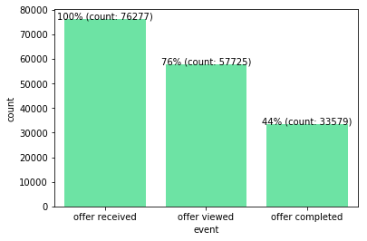

```python
# base count is total number of offers received by all the customers
transcript_subset = transcript[transcript.event.isin(["offer received", "offer viewed", "offer completed"])]
total = float(len(transcript_subset[transcript_subset.event == "offer received"]))
ax = sns.countplot(x="event", data=transcript_subset, color='#5AF6A3')
for p in ax.patches:
    height = p.get_height()
    ax.text(p.get_x()+p.get_width()/2.,
            height + 3,
            '{:1.0f}% (count: {})'.format((height/total)*100, height),
            ha="center")
show()
```

- out of 76.2K received offers only 33.5K (44%) were completed (including auto completed offers).

#### 6.2 gender counts in profile data set

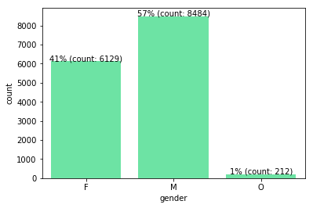

```python
total = float(len(profile))
ax = sns.countplot(x="gender", data=profile, color='#5AF6A3')
for p in ax.patches:
    height = p.get_height()
    ax.text(p.get_x()+p.get_width()/2.,
            height + 3,
            '{:1.0f}% (count: {})'.format((height/total)*100, height),
            ha="center")
show()
```

- percentage of males (57%) is higher compared to females (41%). And percentage of others is very low (1%).

#### 6.3 pair plot age, become_member_on and income

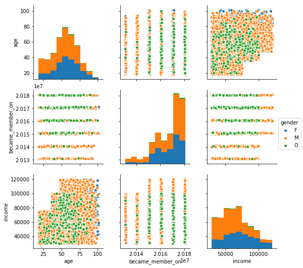

```python
# create pairplot between age, become_member_on and income
sns.pairplot(profile, hue = 'gender')
```

#### 6.4 find the popular offers amoung each gender group

```python
# from customer_data matrix find the most popular offers
l_offers = customer_data.columns[4:15].tolist()
gender_offer_counts = pd.DataFrame(customer_data.groupby('gender')[l_offers].sum())
gender_offer_counts = pd.DataFrame(gender_offer_counts.to_records())
gender_offer_counts
```

|  | gender | offer_0 | offer_1 | offer_2 | offer_3 | offer_4 | offer_5 | offer_6 | offer_7 | offer_8 | offer_9 |
| --- | --- | --- | --- | --- | --- | --- | --- | --- | --- | --- | --- |
| 0 | F | 1419 | 1454 | 0 | 1125 | 674 | 1817 | 1833 | 0 | 1607 | 1075 |
| 1 | M | 1348 | 1310 | 0 | 1218 | 742 | 2184 | 2267 | 0 | 1817 | 1216 |
| 2 | O | 46 | 41 | 0 | 54 | 36 | 61 | 54 | 0 | 57 | 44 |

- "offer_5", "offer_6" and "offer_8" influenced the most Females and Males.

```python
# get the user-item matrix saved in step 3.3
customer_data_3 = pd.read_csv('customer_offer_matrix.csv')

# convert age into age bands
bins = [1, 18, 25, 35, 45, 55, 65, 120]
names = ['<18','19-25', '26-35', '36-45', '46-55', '56-65', '65+']

customer_data_3['age'] = pd.cut(customer_data_3['age'], bins, labels=names)

# rename age as age_band
customer_data_3.rename(columns={'age': 'age_band'}, inplace=True)

'''
# convert income into income bands
bins = [1, 30000, 50000, 70000, 90000, 120000, 150000]
names = ['<30K','30K-50K', '50K-70K', '70K-90K', '90K-120K', '120K+']

customer_data_3['income'] = pd.cut(customer_data_3['income'], bins, labels=names)

# rename income as income_band
customer_data_3.rename(columns={'income': 'income_band'}, inplace=True)
'''

customer_data_3.head()
```

|  | customer_id | age_band | gender | income | offer_0 | offer_1 | offer_2 | offer_3 | offer_4 | offer_5 | offer_6 | offer_7 | offer_8 | offer_9 |
| --- | --- | --- | --- | --- | --- | --- | --- | --- | --- | --- | --- | --- | --- | --- |
| 0 | 0610b486422d4921ae7d2bf64640c50b | 46-55 | F | 112000.0 | 0 | 0 | 0 | 0 | 0 | 0 | 0 | 0 | 0 | 0 |
| 1 | 78afa995795e4d85b5d9ceeca43f5fef | 65+ | F | 100000.0 | 1 | 0 | 0 | 1 | 0 | 0 | 0 | 0 | 1 | 0 |
| 2 | e2127556f4f64592b11af22de27a7932 | 65+ | M | 70000.0 | 0 | 0 | 0 | 1 | 0 | 0 | 1 | 0 | 0 | 0 |
| 3 | 389bc3fa690240e798340f5a15918d5c | 56-65 | M | 53000.0 | 0 | 0 | 0 | 1 | 0 | 0 | 1 | 0 | 1 | 1 |
| 4 | 2eeac8d8feae4a8cad5a6af0499a211d | 56-65 | M | 51000.0 | 0 | 0 | 0 | 0 | 0 | 0 | 1 | 0 | 0 | 0 |

```python
l_offers = customer_data_3.columns[4:14].tolist()
customer_data_3.groupby('age_band')[l_offers].sum()

age_band_offers_completed = pd.DataFrame({'offers_completed' : customer_data_3.groupby('age_band').size()}).reset_index()
age_band_offers_completed
```

|  | age_band | offers_completed |
| --- | --- | --- |
| 0 | <18 | 70 |
| 1 | 19-25 | 942 |
| 2 | 26-35 | 1362 |
| 3 | 36-45 | 1982 |
| 4 | 46-55 | 3132 |
| 5 | 56-65 | 3351 |
| 6 | 65+ | 3986 |

```python
# total offers completed
total_offers_completed = age_band_offers_completed['offers_completed'].sum()
print(total_offers_completed)
```

```
14825
```

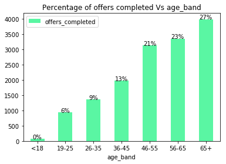

```python
# plot percentage of offers completed in each group
ax = age_band_offers_completed.plot(x="age_band", y='offers_completed',
                                  kind='bar', color='#5AF6A3', rot=0,
                                  title='Percentage of offers completed Vs age_band')
for p in ax.patches:
    height = p.get_height()
    ax.text(p.get_x()+p.get_width()/2.,
            height + 3,
            '{:1.0f}%'.format((height/total_offers_completed)*100, height),
            ha="center")
show()
```

```python
l_offers = list(customer_data_3.columns[4:14])
customer_data_3.groupby('age_band')[l_offers].sum()

age_band_offer_completed = pd.DataFrame(customer_data_3.groupby('age_band')[l_offers].sum()).reset_index()
age_band_offer_completed
```

|  | age_band | offer_0 | offer_1 | offer_2 | offer_3 | offer_4 | offer_5 | offer_6 | offer_7 | offer_8 | offer_9 |
| --- | --- | --- | --- | --- | --- | --- | --- | --- | --- | --- | --- |
| 0 | <18 | 9 | 4 | 0 | 9 | 4 | 22 | 13 | 0 | 16 | 3 |
| 1 | 19-25 | 119 | 108 | 0 | 93 | 51 | 236 | 220 | 0 | 182 | 96 |
| 2 | 26-35 | 193 | 179 | 0 | 163 | 55 | 369 | 366 | 0 | 299 | 138 |
| 3 | 36-45 | 389 | 354 | 0 | 362 | 220 | 544 | 525 | 0 | 435 | 336 |
| 4 | 46-55 | 616 | 649 | 0 | 574 | 335 | 844 | 881 | 0 | 753 | 510 |
| 5 | 56-65 | 699 | 666 | 0 | 532 | 371 | 935 | 1006 | 0 | 826 | 596 |
| 6 | 65+ | 788 | 845 | 0 | 664 | 416 | 1112 | 1143 | 0 | 970 | 656 |

##### Top 3 popular offers among age_bands

- <18: "offer_5", "offer_8", "offer_6".
- 19-25: "offer_5", "offer_6", "offer_8".
- 26-35: "offer_5", "offer_6", "offer_8".
- 36-45: "offer_5", "offer_6", "offer_8".
- 46-55: "offer_6", "offer_5", "offer_8".
- 56-65: "offer_6", "offer_5", "offer_8".
- 65+: "offer_6", "offer_5", "offer_8".
- "offer_5" is the most popular offer among customer having age between 18-45.
- "offer_6" is the most popular offer among customer having age between 46-65+.

### Conclusion

##### Top 3 popular offers among age_bands

- <18: "offer_5", "offer_8", "offer_6".
- 19-25: "offer_5", "offer_6", "offer_8".
- 26-35: "offer_5", "offer_6", "offer_8".
- 36-45: "offer_5", "offer_6", "offer_8".
- 46-55: "offer_6", "offer_5", "offer_8".
- 56-65: "offer_6", "offer_5", "offer_8".
- 65+: "offer_6", "offer_5", "offer_8".
- "offer_5" is the most popular offer among customer having age between 18-45.
- "offer_6" is the most popular offer among customer having age between 46-65+.

#### Interesting and difficult parts

- The were some parts I found interesting and difficult:
  - "User-User Based Collaborative Filtering model" could not handle the cold start problem. That's why I choose to recommend offers using "Rank-Based Recommendations" where "User-User Based Collaborative Filtering model" could not handle. And combining these two models became our "hybrid-model".
  - Handling the ignore offers (the offers automatically completed but never viewed by the customer). As we should not recommend the these offers to a customer if he has completed the offers with out viewing these offers. I need to handle the ignored offers in "User-User Based Collaborative Filtering model" and in "hybrid-model".
  - Model evaluation part very intresting and difficult as well of the project. As I could not use the [sklearn.metrics.mean_absolute_error](https://scikit-learn.org/stable/modules/generated/sklearn.metrics.mean_absolute_error.html) because in the above recommendation models we are recommending new offers that the customer may find interesting. So, the recommended offers meant to be different from the offers initially completed by the customers as provided in the app data. That's why for calculating the MAE I considered the recommended offer as error if it was completed by the customer already or the recommened offer was ignored by the customer already.

#### Improvement

- MAE for the hybrid-model is 0.0020. There were 48 customers were the hybrid-model made recommended offers that were already ignored by those customers. This can be brought down to zero by improving the handling of ignored offers.
- For further improvement "Matrix Factorization" can be compared with these models.